# Hydrologic Data Exploratory Analysis

Hydrology Analyst

2026-02-10

## 1. Data Loading and Metadata Inspection

First, we load the NetCDF file and inspect the internal metadata to understand the dimensions and variables available.

```r
# Check if file exists
if (!file.exists(nc_file_path)) {
  stop("The NetCDF file was not found. Please check the file path.")
}

# Open connection for metadata inspection
nc_data <- nc_open(nc_file_path)

# Print basic file info
# a bit too long
#print(nc_data)
```

### 1.1 Variable and Time Extraction

We verify the time units and calendar format to ensure dates are parsed correctly.

```r
# Extract variable names
vars <- attributes(nc_data$var)$names
print(paste("Variables found:", paste(vars, collapse = ", ")))
```

```
## [1] "Variables found: BASEFLOW"
```

```r
# Inspect time attributes

time_units <- ncatt_get(nc_data, "time", "units")$value
time_calendar <- ncatt_get(nc_data, "time", "calendar")$value

print(paste("Time Units:", time_units))
```

```
## [1] "Time Units: days since 1945-1-1 00:00:00"
```

```r
print(paste("Calendar:", time_calendar))
```

```
## [1] "Calendar: standard"
```

```r
# Close the ncdf4 connection (we will use terra for processing)
nc_close(nc_data)
```

## 2. Load Spatial Raster Data

We use the `terra` package here as it is significantly faster than `raster` for large NetCDF files.

```r
# Load the full dataset
nc_raw <- rast(nc_file_path)

# Extract only the BASEFLOW variable
# Note: Ensure the variable name matches exactly what was found in Section 1
var_name <- "BASEFLOW"
bf_stack <- nc_raw[var_name]

# Verify the stack
print(bf_stack)
```

```
## class       : SpatRaster
## size        : 367, 496, 366  (nrow, ncol, nlyr)
## resolution  : 0.0625, 0.0625  (x, y)
## extent      : -140, -109, 41.0625, 64  (xmin, xmax, ymin, ymax)
## coord. ref. : lon/lat WGS 84 (CRS84) (OGC:CRS84)
## source      : Hydrologic Model Output 1945-2099.nc
## varname     : BASEFLOW (Baseflow out of the bottom layer)
## names       : BASEFLOW_1, BASEFLOW_2, BASEFLOW_3, BASEFLOW_4, BASEFLOW_5, BASEFLOW_6, ...
## unit        : mm
## time (days) : 1945-01-01 to 1946-01-01 (366 steps)
```

```r
# Assign time if not automatically detected correctly
# (Terra usually handles this, but this is a safeguard)
if (all(is.na(time(bf_stack)))) {
  # Logic to manually parse if necessary (based on Section 1 info)
  # This part assumes standard CF-compliant NetCDF
  warning("Time dimension not automatically detected. Check netCDF attributes.")
}
```

## 3. Spatial Visualization (Snapshots)

Let’s visualize the hydrology data for specific dates to ensure the spatial patterns look correct.

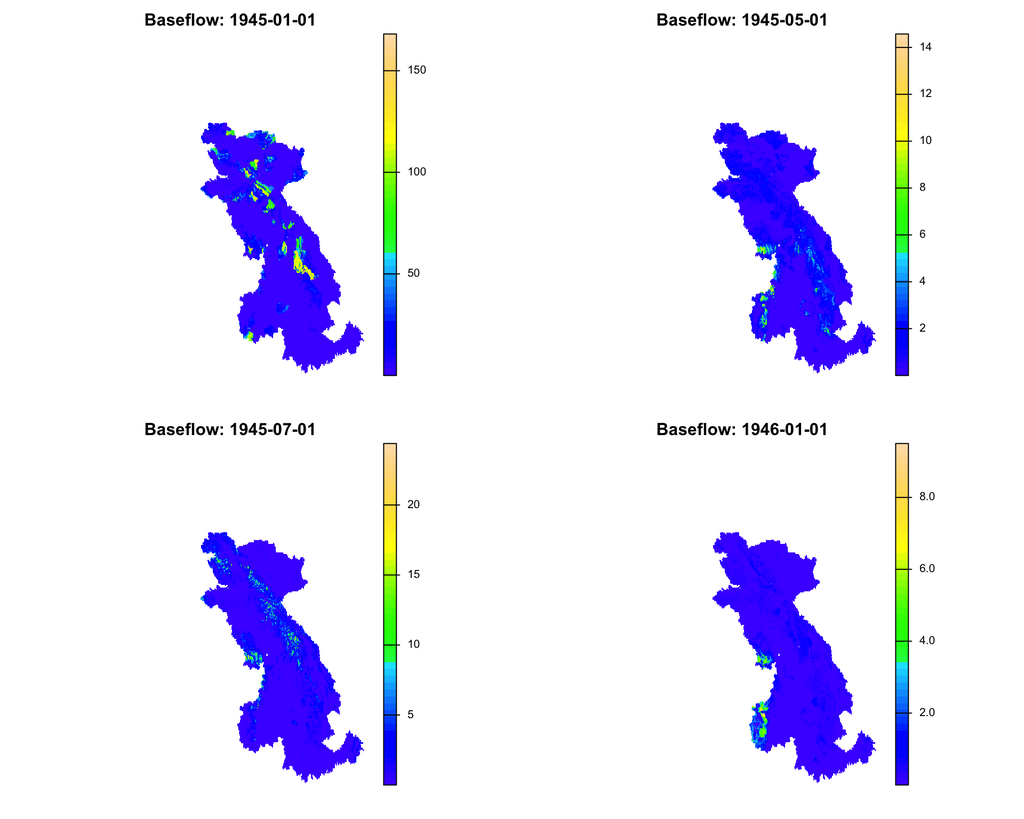

```r
# Define dates to plot
target_dates <- as.Date(c("1945-01-01", "1945-05-01", "1945-07-01", "1946-01-01"))
actual_times <- time(bf_stack)

# Find indices matching these dates
indices <- which(as.Date(actual_times) %in% target_dates)

if (length(indices) > 0) {
  par(mfrow = c(2, 2)) # 2x2 Grid
  for (i in indices) {
    plot(bf_stack[[i]],
         main = paste("Baseflow:", actual_times[i]),
         col = topo.colors(50),
         axes = FALSE)
  }
  par(mfrow = c(1, 1)) # Reset
} else {
  print("Selected dates not found in the dataset.")
}
```

## 4. Aggregate Spatial Analysis

### 4.1 Total Accumulation

We calculate the total baseflow accumulation for the entire duration of the file (pixel-wise sum).

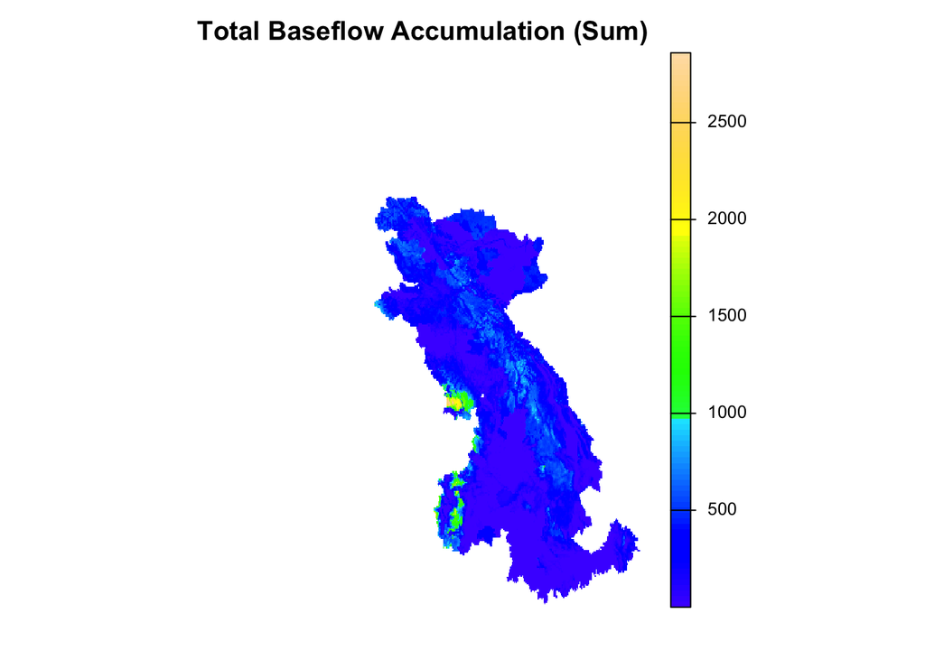

```r
# Calculate sum across all time layers
total_baseflow <- app(bf_stack, sum, na.rm = TRUE)

plot(total_baseflow,
     main = "Total Baseflow Accumulation (Sum)",
     col = topo.colors(100),
     axes = FALSE)
```

### 4.2 Spatial Statistics (Mean vs Volatility)

We compare the average wetness against the standard deviation to identify areas that are consistently wet vs. those that are flashy (storm-driven).

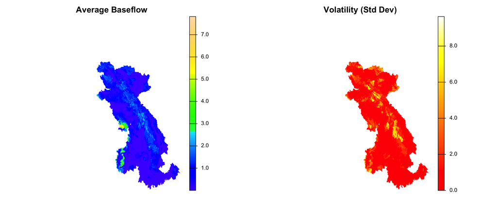

```r
mean_map <- app(bf_stack, mean, na.rm = TRUE)
sd_map   <- app(bf_stack, sd, na.rm = TRUE)

par(mfrow = c(1, 2))
plot(mean_map, main = "Average Baseflow", col = topo.colors(100), axes=FALSE)
plot(sd_map,   main = "Volatility (Std Dev)", col = heat.colors(100), axes=FALSE)
```

```r
par(mfrow = c(1, 1))
```

## 5. Temporal Trends (Global)

Here we aggregate the entire map into a single time series to see the seasonality of the whole region.

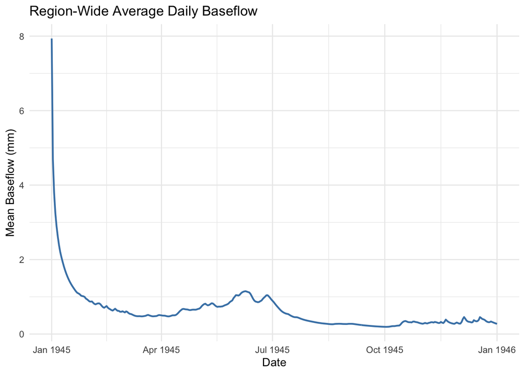

```r
# Calculate the global mean for every time step
daily_avg <- global(bf_stack, "mean", na.rm = TRUE)

# Prepare data for ggplot
df_trend <- data.frame(
  Date = time(bf_stack),
  Baseflow_mm = daily_avg$mean
)

ggplot(df_trend, aes(x = Date, y = Baseflow_mm)) +
  geom_line(color = "steelblue", linewidth = 0.8) +
  theme_minimal() +
  labs(title = "Region-Wide Average Daily Baseflow",
       y = "Mean Baseflow (mm)",
       x = "Date")
```

## 6. Local Analysis (Point Extraction)

We extract a time series for a specific coordinate. To ensure we don’t pick an ocean pixel (NA), we programmatically find a valid land pixel.

```r
# 1. Find valid land coordinates (not NA) from the first layer
first_layer <- bf_stack[[1]]
valid_points <- as.points(first_layer, values=TRUE, na.rm=TRUE)

# 2. Pick a safe sample point (e.g., the 1000th valid point)
# Ensure we don't go out of bounds if the map is small
idx <- min(1000, length(valid_points))
sample_point <- valid_points[idx]
coords <- crds(sample_point)

print(paste("Extracting data for Lat:", round(coords[1,2], 2),
            "Lon:", round(coords[1,1], 2)))
```

```
## [1] "Extracting data for Lat: 57.09 Lon: -119.66"
```

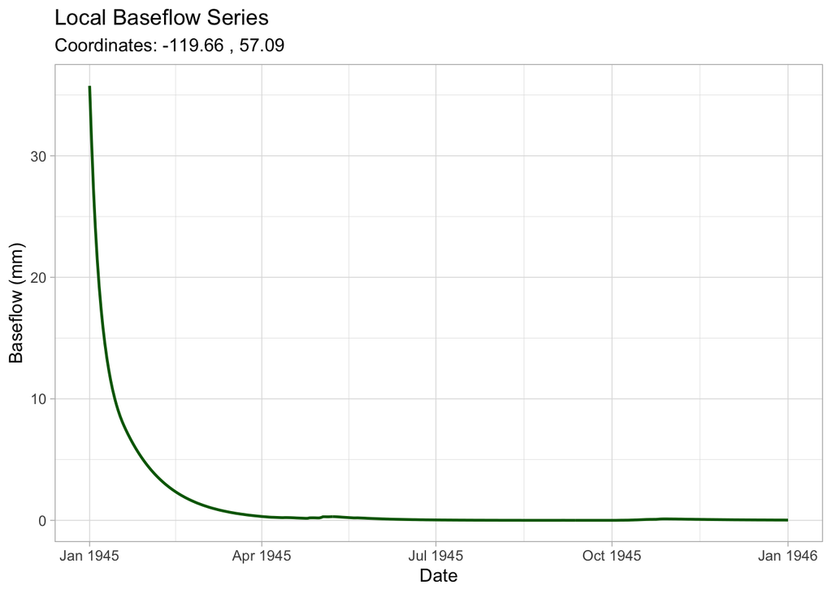

```r
# 3. Extract time series for this location
point_vals <- terra::extract(bf_stack, sample_point, ID=FALSE) # returns a vector

# 4. Create dataframe
point_ts <- data.frame(
  Date = time(bf_stack),
  Baseflow = as.numeric(point_vals)
)

# 5. Plot
ggplot(point_ts, aes(x = Date, y = Baseflow)) +
  geom_line(color = "darkgreen", linewidth = 0.8) +
  theme_light() +
  labs(title = paste("Local Baseflow Series"),
       subtitle = paste("Coordinates:", round(coords[1,1], 2), ",", round(coords[1,2], 2)),
       y = "Baseflow (mm)")
```

## 7. Distribution Analysis

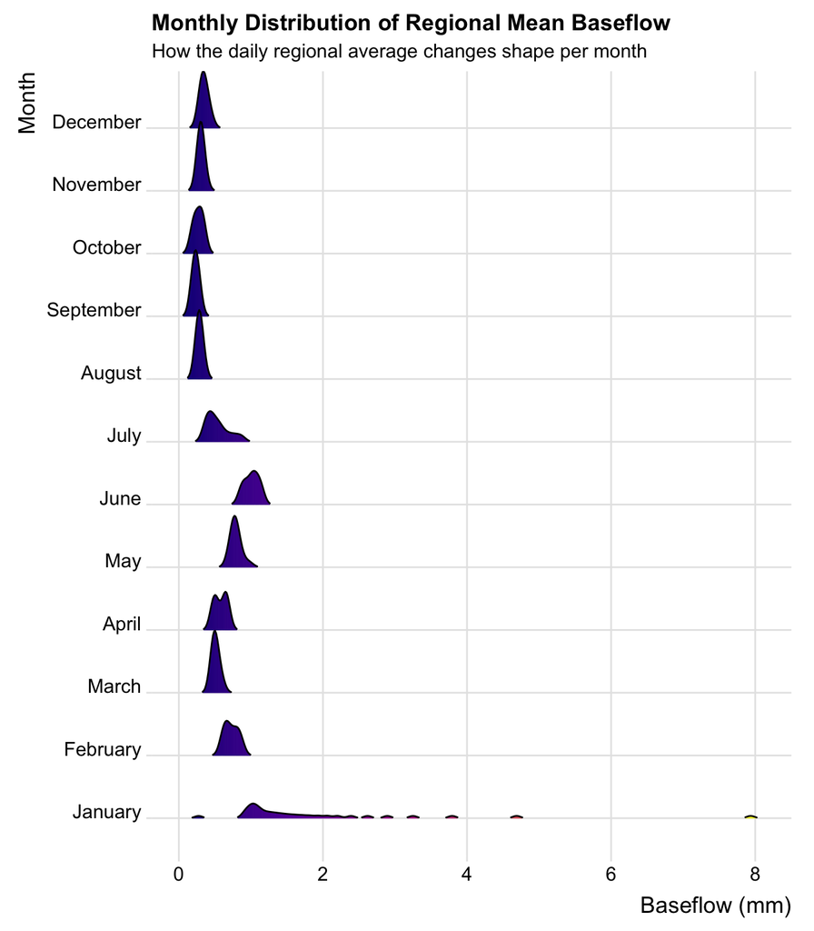

```r
# 1. Sample the data (e.g., 5000 random pixels across all time steps)
# SpatSample with 'across=TRUE' is problematic for large time series memory-wise.
# Strategy: Use the global daily averages to see seasonal shifts in magnitude.

# Create a long format data frame for plotting
df_long <- df_trend %>%
  mutate(
    Month = format(Date, "%B"),
    Month_Num = as.numeric(format(Date, "%m"))
  ) %>%
  arrange(Month_Num) %>%
  mutate(Month = factor(Month, levels = unique(Month)))


library(ggridges)
# Plot Ridge Density
ggplot(df_long, aes(x = Baseflow_mm, y = Month, fill = after_stat(x))) +
  geom_density_ridges_gradient(scale = 1.1, rel_min_height = 0.01) +
  scale_fill_viridis_c(name = "mm", option = "C") +
  labs(title = "Monthly Distribution of Regional Mean Baseflow",
       subtitle = "How the daily regional average changes shape per month",
       x = "Baseflow (mm)") +
  theme_ridges() +
  theme(legend.position = "none")
```

## 8. Interactive Maps for Key Dates

```r
library(terra)
library(leaflet)
n_wettest <- 2  # Number of wettest days to show
target_date <- "1945-07-15"  # Specific date to plot

# ============================================
# Helper Function
# ============================================
create_baseflow_map <- function(layer, title_text) {
  all_values <- terra::values(layer)
  actual_range <- range(all_values, na.rm = TRUE)
  domain_vals <- c(0, actual_range[2])

  pal <- leaflet::colorNumeric(c("#FFFFCC", "#41B6C4", "#0C2C84"),
                                domain = domain_vals,
                                na.color = "transparent")

  leaflet::leaflet() %>%
    leaflet::addProviderTiles(leaflet::providers$CartoDB.Positron) %>%
    leaflet::addRasterImage(layer,
                            colors = pal,
                            opacity = 0.8,
                            project = FALSE,
                            maxBytes = 20 * 1024 * 1024) %>%
    leaflet::addLegend(pal = pal,
                       values = all_values,
                       title = title_text)
}

# ============================================
# 1. Top N Wettest Days
# ============================================
daily_means <- global(bf_stack, "mean", na.rm = TRUE)
top_indices <- order(daily_means$mean, decreasing = TRUE)[1:n_wettest]
top_dates <- time(bf_stack)[top_indices]

top_maps <- lapply(1:n_wettest, function(i) {
  layer <- bf_stack[[top_indices[i]]]
  map_title <- sprintf("Rank %d - %s", i, top_dates[i])
  create_baseflow_map(layer, map_title)
})

# Display all top maps
htmltools::tagList(top_maps)
```

[interactive chart not shown]

```r
# ============================================
# 2. Specific Date Map
# ============================================
specific_date <- as.Date(target_date)
date_index <- which(time(bf_stack) == specific_date)

if(length(date_index) > 0) {
  cat("\n=== Specific Date Map ===\n")
  cat(sprintf("Date: %s (Day %d)\n", specific_date, date_index))
  cat(sprintf("Mean flow: %.2f mm\n", daily_means$mean[date_index]))

  specific_layer <- bf_stack[[date_index]]
  create_baseflow_map(specific_layer, paste("Baseflow on", specific_date))
} else {
  cat("\n⚠ Date", target_date, "not found in dataset\n")
  cat("Available range:", as.character(min(time(bf_stack))),
      "to", as.character(max(time(bf_stack))), "\n")
}
```

```
##
## === Specific Date Map ===
## Date: 1945-07-15 (Day 196)
## Mean flow: 0.51 mm
```

[interactive chart not shown]